# Séance 1 : Exercices (corrigés)

Cécile Armand

2025-10-01

# QCM

Testez vos connaissances en répondant à ce [questionnaire](https://forms.gle/E9eQhkTDDL8PJ8fFA).

Consulter les réponses.

# Main à la pâte

Le petit exercice qui suit a pour objectif de vous exercer à utiliser les fonctions introduites pendant la première séance, à partir d’un autre jeu de données similaire à celui utilisé pendant le cours.

Le jeu de données proposé se base sur un annuaire d’étudiants chinois aux Etats-Unis paru en 1917 (*Who’s Who of American returned students*), accessible en full text sur Wikisource. Il contient plus de 400 étudiants avec des informations sur leurs origines, leur parcours d’éducation, leur carrière et d’autres informations biographiques (participation à des clubs, publications, récompenses, etc). Les données ont été extraites automatiquement en utilisant différentes techniques de traitement automatique des langues (TAL) puis nettoyées manuellement.

## Chargez le fichier

Chargez le fichier *youmei.csv*.

```r
library(readr)
youmei <- read_csv("~/RClass/Cours1/youmei.csv", col_types = cols(...1 = col_skip()))
```

## Inspectez les données

1. Combien y a-t-il d’observations ? Combien de variables ?
2. Lister les 10 premiers étudiants.
3. Lister toutes les variables. Combien y a-t-il de variables numériques ?
4. Certaines variables contiennent-elles des données manquantes ? Lesquelles ?
5. Lister les étudiants pour lesquelles les informations sont complètes.

```r
# Réponse 1 : 401 observations (étudiants) et 38 variables

# Réponse 2

head(youmei, n = 10)
```

```
## # A tibble: 10 × 38
##    DocId  page name_source FullName_zh FullName_py FullName_wg gender birth_year
##    <chr> <dbl> <chr>       <chr>       <chr>       <chr>       <chr>       <dbl>
##  1 imh-…    10 胡其炳      胡其炳      Hu Qibing   Hu C. P.    Male         1872
##  2 imh-…    19 施肇基      施肇基      Shi Zhaoji  Sze Sao-Ke… Male         1876
##  3 imh-…    24 徐良        徐良        Xu Liang    Chui Leong  Male         1892
##  4 imh-…    28 徐崇欽      徐崇欽      Xu Chongqin Zee C. J    Male         1878
##  5 imh-…    29 徐可陞      徐可陞      Xu Kesheng  Zee Ko-Seng Male         1884
##  6 imh-…    34 夏元瑮      夏元瑮      Jia Yuanli  Hsia Yuan-… Male         1884
##  7 imh-…    36 梁鑾        梁鑾        Liang Luan  Leung Louis Male         1887
##  8 imh-…    37 梁啟勳      梁啟勳      Liang Qixun Liang Chi-… Male           NA
##  9 imh-…    49 孫鳳珠      孫鳳珠      Sun Fengzhu Sung Vong-… Female       1893
## 10 imh-…    66 陳維屛      陳維屛      Chen Weipi… Chen Wei-P… Male         1876
## # ℹ 30 more variables: age_in_1917 <dbl>, Birth_Province_zh <chr>,
## #   Birth_Province_eng_standard <chr>, Birth_location_zh <chr>,
## #   Birth_Location_eng_standard <chr>, ancestry_province <chr>,
## #   ancestry_locality <chr>, married <chr>, married_year <dbl>,
## #   marriage_age <dbl>, sons <dbl>, daugthers <dbl>, total_children <dbl>,
## #   Funding <chr>, arrived_year <dbl>, arrived_month <chr>,
## #   estimated_arrived_year <dbl>, period <chr>, arrived_cohort <chr>, …
```

```r
# Réponse 3

names(youmei)
```

```
##  [1] "DocId"                       "page"
##  [3] "name_source"                 "FullName_zh"
##  [5] "FullName_py"                 "FullName_wg"
##  [7] "gender"                      "birth_year"
##  [9] "age_in_1917"                 "Birth_Province_zh"
## [11] "Birth_Province_eng_standard" "Birth_location_zh"
## [13] "Birth_Location_eng_standard" "ancestry_province"
## [15] "ancestry_locality"           "married"
## [17] "married_year"                "marriage_age"
## [19] "sons"                        "daugthers"
## [21] "total_children"              "Funding"
## [23] "arrived_year"                "arrived_month"
## [25] "estimated_arrived_year"      "period"
## [27] "arrived_cohort"              "age_arrival"
## [29] "returned_year"               "returned_month"
## [31] "estimated_returned_year"     "returned_cohort"
## [33] "duration"                    "age_return"
## [35] "field_of_study"              "field_group"
## [37] "field_code"                  "field2_code"
```

```r
summary(youmei) # 15
```

```
##     DocId                page       name_source        FullName_zh
##  Length:401         Min.   :  1.0   Length:401         Length:401
##  Class :character   1st Qu.: 56.0   Class :character   Class :character
##  Mode  :character   Median :109.0   Mode  :character   Mode  :character
##                     Mean   :108.1
##                     3rd Qu.:160.0
##                     Max.   :215.0
##
##  FullName_py        FullName_wg           gender            birth_year
##  Length:401         Length:401         Length:401         Min.   :1851
##  Class :character   Class :character   Class :character   1st Qu.:1881
##  Mode  :character   Mode  :character   Mode  :character   Median :1886
##                                                           Mean   :1884
##                                                           3rd Qu.:1889
##                                                           Max.   :1895
##                                                           NA's   :25
##   age_in_1917    Birth_Province_zh  Birth_Province_eng_standard
##  Min.   :22.00   Length:401         Length:401
##  1st Qu.:28.00   Class :character   Class :character
##  Median :31.00   Mode  :character   Mode  :character
##  Mean   :32.84
##  3rd Qu.:36.00
##  Max.   :66.00
##  NA's   :25
##  Birth_location_zh  Birth_Location_eng_standard ancestry_province
##  Length:401         Length:401                  Length:401
##  Class :character   Class :character            Class :character
##  Mode  :character   Mode  :character            Mode  :character
##
##
##
##
##  ancestry_locality    married           married_year   marriage_age
##  Length:401         Length:401         Min.   :1871   Min.   : 7.00
##  Class :character   Class :character   1st Qu.:1905   1st Qu.:22.00
##  Mode  :character   Mode  :character   Median :1910   Median :25.00
##                                        Mean   :1908   Mean   :25.05
##                                        3rd Qu.:1914   3rd Qu.:28.00
##                                        Max.   :1917   Max.   :47.00
##                                        NA's   :148    NA's   :157
```

[output cut: 25 more lines]

```
##  Min.   :1881            Length:401         Min.   : 1.000   Min.   :18.00
##  1st Qu.:1911            Class :character   1st Qu.: 4.000   1st Qu.:24.75
##  Median :1913            Mode  :character   Median : 5.000   Median :27.00
##  Mean   :1911                               Mean   : 5.552   Mean   :27.18
##  3rd Qu.:1915                               3rd Qu.: 6.250   3rd Qu.:29.00
##  Max.   :1917                               Max.   :30.000   Max.   :46.00
##  NA's   :6                                  NA's   :17       NA's   :29
##  field_of_study     field_group         field_code        field2_code
##  Length:401         Length:401         Length:401         Length:401
##  Class :character   Class :character   Class :character   Class :character
##  Mode  :character   Mode  :character   Mode  :character   Mode  :character
##
##
##
##
```

```r
# Réponse 4

colSums(is.na(youmei))
```

```
##                       DocId                        page
##                           0                           0
##                 name_source                 FullName_zh
##                           0                           0
##                 FullName_py                 FullName_wg
##                           0                           0
##                      gender                  birth_year
##                           0                          25
##                 age_in_1917           Birth_Province_zh
##                          25                           3
## Birth_Province_eng_standard           Birth_location_zh
##                           2                          15
## Birth_Location_eng_standard           ancestry_province
##                          14                         397
##           ancestry_locality                     married
##                         398                          40
##                married_year                marriage_age
##                         148                         157
##                        sons                   daugthers
##                           0                           0
##              total_children                     Funding
##                           0                           0
##                arrived_year               arrived_month
##                          23                          53
##      estimated_arrived_year                      period
##                          12                           1
##              arrived_cohort                 age_arrival
##                          53                          34
##               returned_year              returned_month
##                          20                          52
##     estimated_returned_year             returned_cohort
##                           6                          53
##                    duration                  age_return
##                          17                          29
##              field_of_study                 field_group
##                           4                           4
##                  field_code                 field2_code
##                           4                           4
```

```r
# Réponse 5

youmei[complete.cases(youmei), ] # un seul cas : imh-11-103
```

```
## # A tibble: 1 × 38
##   DocId   page name_source FullName_zh FullName_py FullName_wg gender birth_year
##   <chr>  <dbl> <chr>       <chr>       <chr>       <chr>       <chr>       <dbl>
## 1 imh-1…     4 周詒春      周詒春      Zhou Yichun Tsur Ye-Ts… Male         1883
## # ℹ 30 more variables: age_in_1917 <dbl>, Birth_Province_zh <chr>,
## #   Birth_Province_eng_standard <chr>, Birth_location_zh <chr>,
## #   Birth_Location_eng_standard <chr>, ancestry_province <chr>,
## #   ancestry_locality <chr>, married <chr>, married_year <dbl>,
## #   marriage_age <dbl>, sons <dbl>, daugthers <dbl>, total_children <dbl>,
## #   Funding <chr>, arrived_year <dbl>, arrived_month <chr>,
## #   estimated_arrived_year <dbl>, period <chr>, arrived_cohort <chr>, …
```

## Rationaliser

Le jeu de données contient beaucoup de colonnes. Simplifiez-le de manière à éliminer les informations redondantes et conserver les informations les plus complètes. Conservez uniquement les colonnes suivantes, dans l’ordre indiqué, et renommez-les de manière claire, comme proposé dans le tableau ci-dessous. Veillez à ne pas écraser le jeu de données d’origine.

| Ordre | Nom d’origine | Nom après renommage |
| --- | --- | --- |
| 1 | DocId | identifiant_source |
| 2 | FullName_py | nom |
| 3 | gender | genre |
| 4 | birth_year | annee_naissance |
| 5 | Birth_Province_eng_standard | province_naissance |
| 6 | Birth_Location_eng_standard | ville_naissance |
| 7 | Funding | financement |
| 8 | field_group | discipline |
| 9 | estimated_arrived_year | annee_arrivee_USA |
| 10 | estimated_returned_year | annee_retour_Chine |

```r
youmei_clean <- youmei %>% select(DocId, FullName_py, gender,
                                  birth_year, Birth_Province_eng_standard, Birth_Location_eng_standard,
                                  Funding, field_group,
                                  estimated_arrived_year, estimated_returned_year) %>%
  rename(
    identifiant_source = DocId,
    nom               = FullName_py,
    genre             = gender,
    annee_naissance   = birth_year,
    province_naissance= Birth_Province_eng_standard,
    ville_naissance   = Birth_Location_eng_standard,
    financement= Funding,
    discipline     = field_group,
    annee_arrivee_USA = estimated_arrived_year,
    annee_retour_Chine= estimated_returned_year)
```

## Explorez les données

1. Combien y a-t-il désormais d’individus avec des données complètes ?
2. Combien y a-t-il d’étudiantes ? Quel pourcentage de la population totale représentent-elles (arrondir à 1 décimale) ?
3. Identifier l’individu le plus âgé/le plus jeune et spécifier leur année de naissance.
4. Visualiser la distribution des années de naissance sous forme d’histogramme.
5. Analyser la distribution des étudiants selon leur province de naissance (en nombre et pourcentage)
6. Combien y a-t-il d’étudiants boursiers vs. auto-financés ? (Créer un nouvelle variable pour réduire à deux catégories)
7. Comment se répartissent les étudiants par discipline ?
8. Comparer le domaine d’étude selon le genre.
9. Calculer la durée moyenne des études.
10. Calculer l’âge au départ et au retour (créer un nouvelle variable à chaque fois).

```r
# 1. Combien y a-t-il désormais d'individus avec des données complètes ?

youmei_clean[complete.cases(youmei_clean), ] # 355
```

```
## # A tibble: 355 × 10
##    identifiant_source nom             genre  annee_naissance province_naissance
##    <chr>              <chr>           <chr>            <dbl> <chr>
##  1 imh-11-111         Hu Qibing       Male              1872 Jiangxi
##  2 imh-11-127         Shi Zhaoji      Male              1876 Jiangsu
##  3 imh-11-136         Xu Liang        Male              1892 Guangdong
##  4 imh-11-144         Xu Kesheng      Male              1884 Zhejiang
##  5 imh-11-152         Jia Yuanli      Male              1884 Zhejiang
##  6 imh-11-155         Liang Luan      Male              1887 Guangdong
##  7 imh-11-176         Sun Fengzhu     Female            1893 Jiangsu
##  8 imh-11-204         Chen Weiping    Male              1876 Hebei
##  9 imh-11-230         Zhang Yuanshan  Male              1892 Jiangsu
## 10 imh-11-245         Huang Rongliang Male              1876 Anhui
## # ℹ 345 more rows
## # ℹ 5 more variables: ville_naissance <chr>, financement <chr>,
## #   discipline <chr>, annee_arrivee_USA <dbl>, annee_retour_Chine <dbl>
```

```r
# 2. Combien y a-t-il d'étudiantes ?  # 18, 4.5%

youmei_clean %>% group_by(genre) %>% count() %>% mutate(percent = round(n/401*100, 1))
```

```
## # A tibble: 2 × 3
## # Groups:   genre [2]
##   genre      n percent
##   <chr>  <int>   <dbl>
## 1 Female    18     4.5
## 2 Male     383    95.5
```

```r
# 3. Identifier l'individu le plus âgé/le plus jeune et spécifier leur année de naissance.

# Identifier d'abord les années

min(youmei_clean$annee_naissance, na.rm = T) # le plus âgé (1851)
```

```
## [1] 1851
```

```r
max(youmei_clean$annee_naissance, na.rm = T)  # le plus jeune (1895)
```

```
## [1] 1895
```

```r
# Identifier les individus correspondants

# Le plus âgé (année de naissance la plus petite)
youmei_clean[which.min(youmei_clean$annee_naissance), ] # Liang Dunyan (1851)
```

```
## # A tibble: 1 × 10
##   identifiant_source nom          genre annee_naissance province_naissance
##   <chr>              <chr>        <chr>           <dbl> <chr>
## 1 imh-11-161         Liang Dunyan Male             1851 Guangdong
## # ℹ 5 more variables: ville_naissance <chr>, financement <chr>,
## #   discipline <chr>, annee_arrivee_USA <dbl>, annee_retour_Chine <dbl>
```

```r
# Le plus jeune (année de naissance la plus grande)
youmei_clean[which.max(youmei_clean$annee_naissance), ] # Tang Ruihua (1895)
```

```
## # A tibble: 1 × 10
##   identifiant_source nom         genre annee_naissance province_naissance
##   <chr>              <chr>       <chr>           <dbl> <chr>
## 1 imh-11-180         Tang Ruihua Male             1895 Jiangsu
## # ℹ 5 more variables: ville_naissance <chr>, financement <chr>,
## #   discipline <chr>, annee_arrivee_USA <dbl>, annee_retour_Chine <dbl>
```

```r
# Alternative avec dplyr

# Le plus âgé
youmei_clean %>%
  slice_min(order_by = annee_naissance, n = 1)
```

```
## # A tibble: 1 × 10
##   identifiant_source nom          genre annee_naissance province_naissance
##   <chr>              <chr>        <chr>           <dbl> <chr>
## 1 imh-11-161         Liang Dunyan Male             1851 Guangdong
## # ℹ 5 more variables: ville_naissance <chr>, financement <chr>,
## #   discipline <chr>, annee_arrivee_USA <dbl>, annee_retour_Chine <dbl>
```

```r
# Le plus jeune
youmei_clean %>%
  slice_max(order_by = annee_naissance, n = 1)
```

```
## # A tibble: 1 × 10
##   identifiant_source nom         genre annee_naissance province_naissance
##   <chr>              <chr>       <chr>           <dbl> <chr>
## 1 imh-11-180         Tang Ruihua Male             1895 Jiangsu
## # ℹ 5 more variables: ville_naissance <chr>, financement <chr>,
## #   discipline <chr>, annee_arrivee_USA <dbl>, annee_retour_Chine <dbl>
```

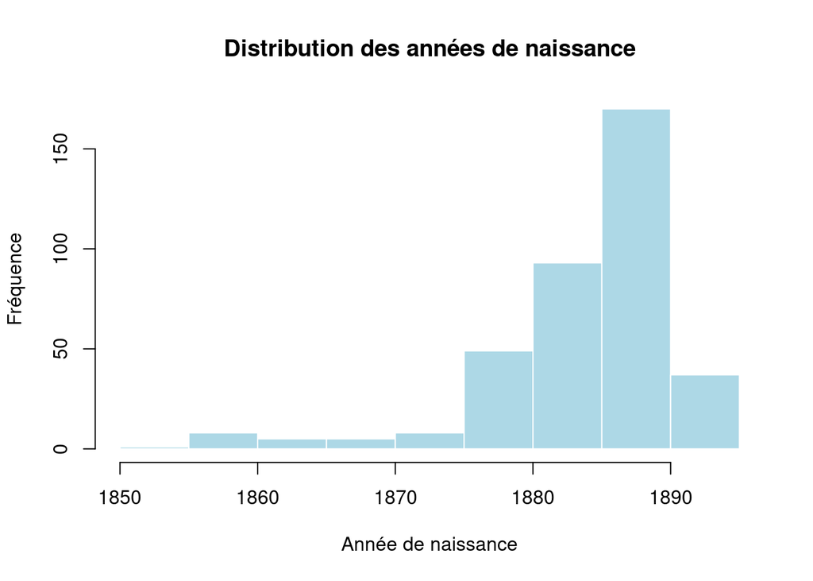

```r
# 4. Visualiser la distribution des années de naissance sous forme d'histogramme.

# Avec base R

hist(youmei_clean$annee_naissance,
     main = "Distribution des années de naissance",
     xlab = "Année de naissance",
     ylab = "Fréquence",
     col = "lightblue",
     border = "white")
```

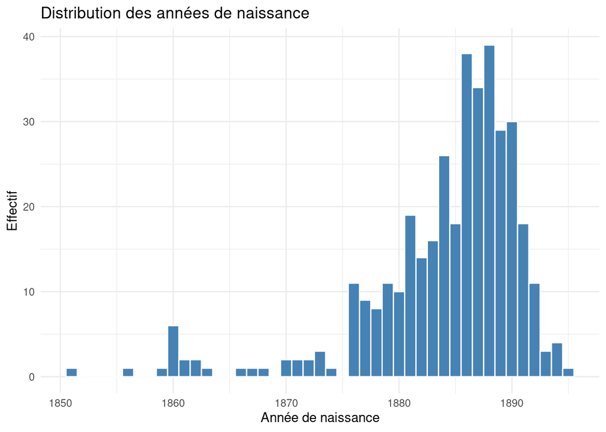

```r
# Avec ggplot

library(ggplot2)

ggplot(youmei_clean, aes(x = annee_naissance)) +
  geom_histogram(binwidth = 1,
                 fill = "steelblue",
                 color = "white") +
  labs(title = "Distribution des années de naissance",
       x = "Année de naissance",
       y = "Effectif") +
  theme_minimal()
```

```r
# 5. Calculer la distribution des étudiants selon leur province de naissance.

youmei_clean %>% group_by(province_naissance) %>%
  count(sort = TRUE) %>%
  mutate(percent = round(n/401*100, 2))
```

```
## # A tibble: 22 × 3
## # Groups:   province_naissance [22]
##    province_naissance     n percent
##    <chr>              <int>   <dbl>
##  1 Jiangsu              137   34.2
##  2 Guangdong            102   25.4
##  3 Zhejiang              39    9.73
##  4 Hebei                 23    5.74
##  5 Fujian                17    4.24
##  6 Hubei                 17    4.24
##  7 Jiangxi               10    2.49
##  8 Anhui                  8    2
##  9 Hawaii                 7    1.75
## 10 Zhili                  7    1.75
## # ℹ 12 more rows
```

```r
# 6. Combien y a-t-il d'étudiants boursiers vs. auto-financés ?

youmei_clean %>% group_by(financement) %>%
  count(sort = TRUE) %>%
  mutate(percent = round(n/401*100, 2))
```

```
## # A tibble: 4 × 3
## # Groups:   financement [4]
##   financement            n percent
##   <chr>              <int>   <dbl>
## 1 Government support   192   47.9
## 2 Private support      146   36.4
## 3 Unknown               32    7.98
## 4 Partial support       31    7.73
```

```r
# Regrouper en deux catégories

# Option 1 (avec ifelse)

youmei_clean$financement2 <- ifelse(youmei_clean$financement == "Government support",
                                    "Public", "Privé")


# Option 2 (avec case.when)

library(dplyr)

youmei_clean <- youmei_clean %>%
  mutate(financement2 = case_when(
    financement == "Government support" ~ "Public",
    financement %in% c("Private support", "Partial support", "Unknown") ~ "Privé",
    TRUE ~ NA_character_
  )) %>%
  relocate(financement2, .after = financement)



# Option 3 (avec forcats)

library(dplyr)
library(forcats)

youmei_clean <- youmei_clean %>%
  mutate(financement2 = fct_recode(as.factor(financement),
                                   "Public" = "Government support",
                                   "Privé"  = "Private support",
                                   "Privé"  = "Partial support",
                                   "Privé"  = "Unknown")) %>%
  relocate(financement2, .after = financement)


# Vérifier le résultat

table(youmei_clean$financement2)
```

```
##
## Public  Privé
##    192    209
```

```r
count(youmei_clean, financement2)
```

```
## # A tibble: 2 × 2
##   financement2     n
##   <fct>        <int>
## 1 Public         192
## 2 Privé          209
```

```r
prop.table(table(youmei_clean$financement2)) * 100
```

```
##
##  Public   Privé
## 47.8803 52.1197
```

```r
# 7. Comment se répartissent les étudiants par discipline ?

youmei_clean %>% group_by(discipline) %>% count(sort = TRUE) %>% mutate(percent = round(n/401*100, 2))
```

```
## # A tibble: 8 × 3
## # Groups:   discipline [8]
##   discipline             n percent
##   <chr>              <int>   <dbl>
## 1 Social Sciences      137   34.2
## 2 Engineering          112   27.9
## 3 Sciences              47   11.7
## 4 Multi-disciplinary    38    9.48
## 5 Humanities            32    7.98
## 6 Professional          24    5.99
## 7 Military               7    1.75
## 8 <NA>                   4    1
```

```r
# 8. Comparer le domaine d'étude selon le genre.

youmei_clean %>% group_by(genre, discipline) %>% count(sort = TRUE)
```

```
## # A tibble: 13 × 3
## # Groups:   genre, discipline [13]
##    genre  discipline             n
##    <chr>  <chr>              <int>
##  1 Male   Social Sciences      131
##  2 Male   Engineering          112
##  3 Male   Sciences              46
##  4 Male   Multi-disciplinary    37
##  5 Male   Humanities            23
##  6 Male   Professional          23
##  7 Female Humanities             9
##  8 Male   Military               7
##  9 Female Social Sciences        6
## 10 Male   <NA>                   4
## 11 Female Multi-disciplinary     1
## 12 Female Professional           1
## 13 Female Sciences               1
```

```r
# 9. Calculer la durée moyenne des études.

youmei_clean <- youmei_clean %>% mutate(duree = annee_retour_Chine - annee_arrivee_USA)

mean(youmei_clean$duree, na.rm = T)
```

```
## [1] 5.552083
```

```r
# Option 1 (fonctions de base)

min(youmei_clean$duree, na.rm = TRUE)   # durée minimum
```

```
## [1] 1
```

```r
max(youmei_clean$duree, na.rm = TRUE)   # durée maximum
```

```
## [1] 30
```

```r
mean(youmei_clean$duree, na.rm = TRUE)  # moyenne
```

```
## [1] 5.552083
```

```r
sd(youmei_clean$duree, na.rm = TRUE)    # écart-type
```

```
## [1] 3.05603
```

```r
# Option 2 (summary)

summary(youmei_clean$duree)
```

```
##    Min. 1st Qu.  Median    Mean 3rd Qu.    Max.    NA's
##   1.000   4.000   5.000   5.552   6.250  30.000      17
```

```r
# Option 3 (summarize)

library(dplyr)

youmei_clean %>%
  summarise(
    min_duree = min(duree, na.rm = TRUE),
    max_duree = max(duree, na.rm = TRUE),
    moy_duree = mean(duree, na.rm = TRUE),
    sd_duree  = sd(duree, na.rm = TRUE)
  )
```

```
## # A tibble: 1 × 4
##   min_duree max_duree moy_duree sd_duree
##       <dbl>     <dbl>     <dbl>    <dbl>
## 1         1        30      5.55     3.06
```

```r
# 10. Calculer l'âge au départ et au retour (créer un nouvelle variable à chaque fois).

youmei_clean <- youmei_clean %>% mutate(age_arrivee = annee_arrivee_USA - annee_naissance,
                                        age_retour = annee_retour_Chine - annee_naissance)
```

## Pour aller plus loin

1. L’origine géographique conditionne-t-elle l’obtention d’une bourse ?
2. Le financement a-t-il une influence sur le choix de la discipline ?
3. La durée des études dépend-elle de la discipline ?
4. La durée des études évolue-t-elle au fil des générations ?

**Indices** :

- Pour (1) et (2), corréler les variables deux à deux en utilisant l’analyse de correspondance.
- Pour (3) penser à utiliser nuage de points et diagrammes en boîte

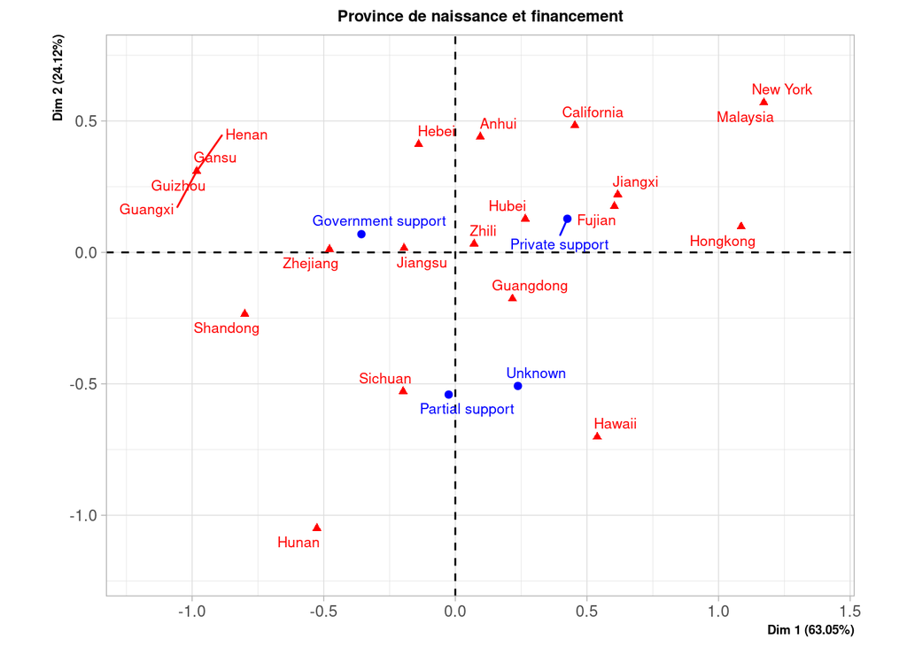

```r
#   1. L'origine géographique conditionne-t-elle l'obtention d'une bourse ?

# Sélectionner les variables à croiser

youmei_province_funding <- youmei_clean %>%
  drop_na(province_naissance, financement) %>%
  group_by(province_naissance, financement) %>%
  tally() %>%
  pivot_wider(names_from = province_naissance,
              values_from = n, values_fill = 0)


# on convertit la colonne des provinces en noms de lignes

library(tidyverse)

youmei_province_funding_ca <- column_to_rownames(youmei_province_funding, var = "financement")

# on applique l'analyse des correspondances

library(FactoMineR)

res.ca <- CA(youmei_province_funding_ca, graph = FALSE)

plot.CA(res.ca, title="Province de naissance et financement", cex=0.7, cex.main=0.8, cex.axis=0.7)
```

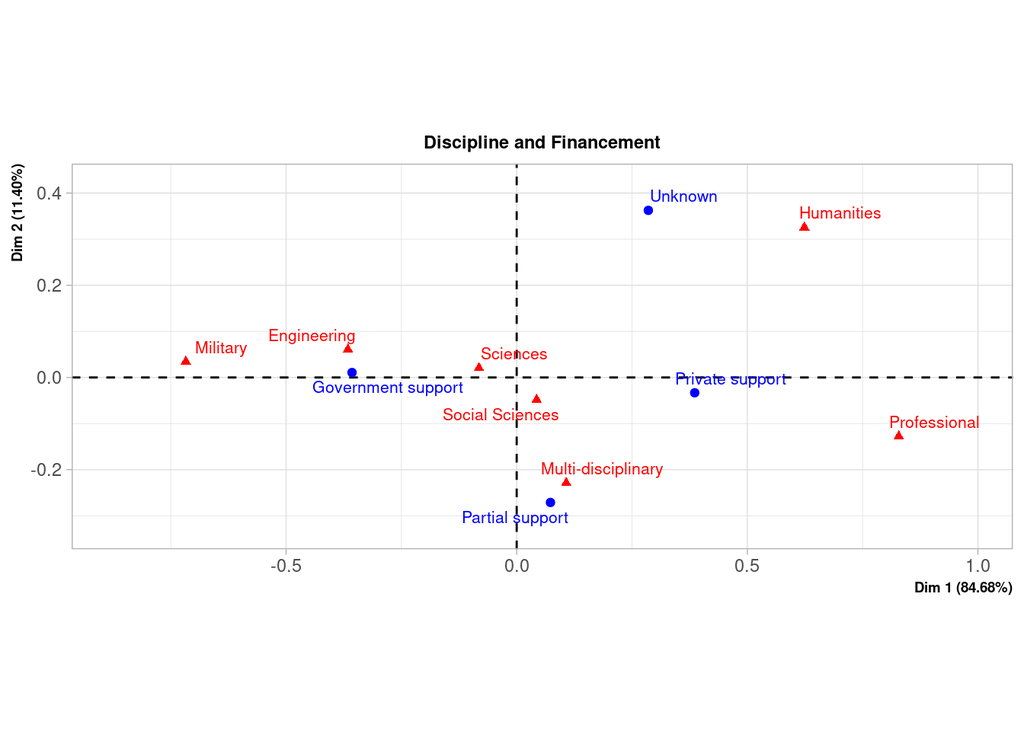

```r
# 2. Le financement a-t-il une influence sur le choix de la discipline ?

# Sélectionner les variables à croiser

youmei_field_funding <- youmei_clean %>%
  drop_na(discipline, financement) %>%
  group_by(discipline, financement) %>%
  tally() %>%
  pivot_wider(names_from = discipline,
              values_from = n, values_fill = 0)


# on convertit la colonne des disciplines en noms de lignes

library(tidyverse)

youmei_field_funding_ca <- column_to_rownames(youmei_field_funding, var = "financement")

# on applique l'analyse des correspondances

library(FactoMineR)

res.ca2 <- CA(youmei_field_funding_ca, graph = FALSE)

plot.CA(res.ca2, title="Discipline and Financement", cex=0.7, cex.main=0.8, cex.axis=0.7)
```

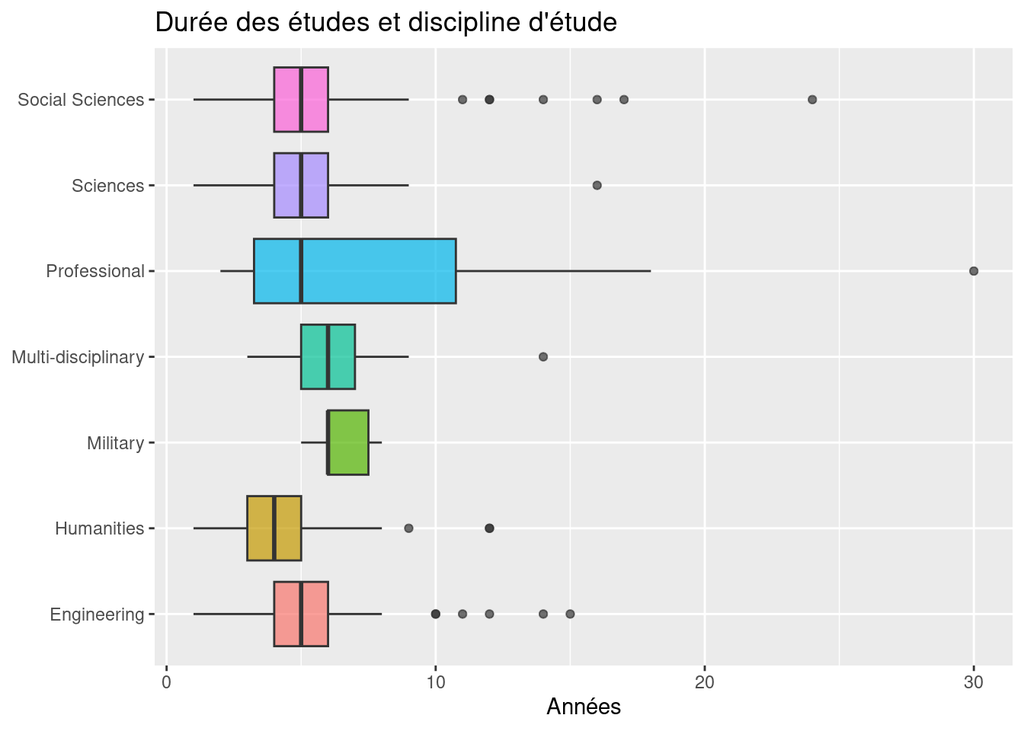

```r
# 3. La durée des études dépend-elle de la discipline ?

youmei_clean %>%
  filter(!is.na(duree)) %>%
    filter(!is.na(discipline)) %>%
  ggplot(aes(x= discipline, y = duree, fill = discipline)) +
  geom_boxplot(alpha = 0.7, show.legend = FALSE) +
  coord_flip() +
  labs(title = "Durée des études et discipline d'étude",
       x = NULL,
       y = "Années",
       fill = NULL)
```

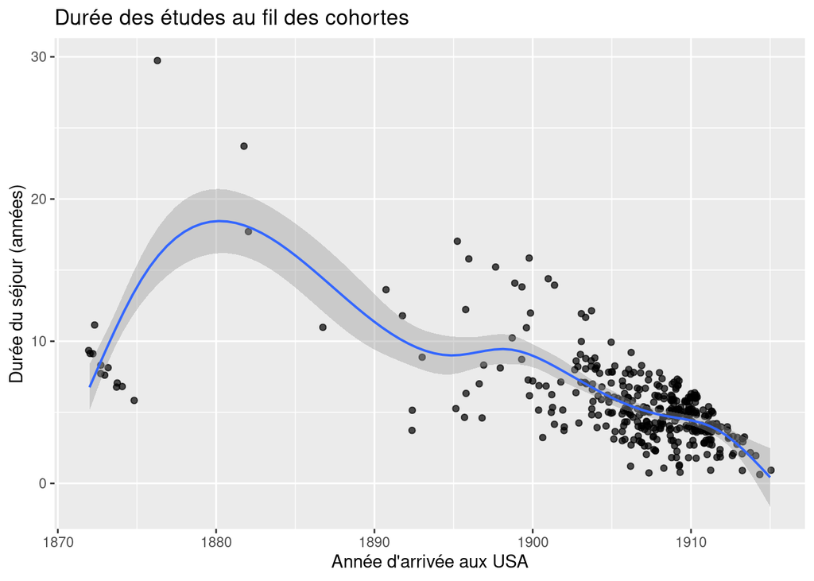

```r
# 4. La durée des études évolue-t-elle au fil des générations ?

# Option 1 : nuage de points croisant année d'arrivée (horizontal) et durée du séjour (vertical)

youmei_clean %>%
  ggplot(aes(annee_arrivee_USA, duree)) +
  geom_jitter(alpha = 0.7) +
  geom_smooth(method = "gam", se = TRUE, linewidth = 0.7) +
  labs(title = "Durée des études au fil des cohortes",
       x = "Année d'arrivée aux USA",
       y = "Durée du séjour (années)")
```

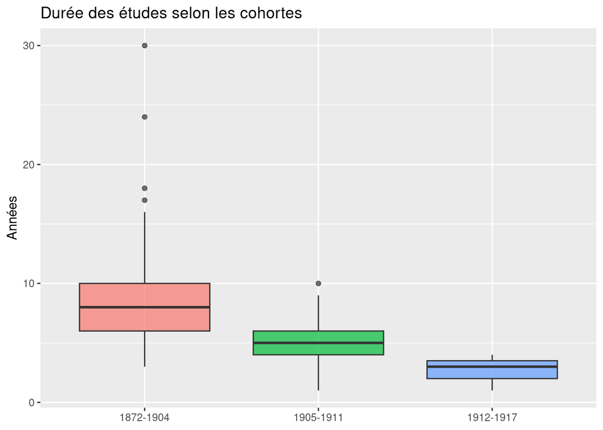

```r
# Option 2 : créer une variable "génération" et comparer la durée des études à travers les groupes avec des boxplots

youmei_clean <- youmei_clean %>%
  mutate(
    generation = case_when(
      annee_arrivee_USA >= 1872 & annee_arrivee_USA <= 1904 ~ "1872-1904",
      annee_arrivee_USA >= 1905 & annee_arrivee_USA <= 1911 ~ "1905-1911",
      annee_arrivee_USA >= 1912 & annee_arrivee_USA <= 1917 ~ "1912-1917",
      TRUE ~ NA_character_   # pour les valeurs hors bornes
    )
  )

youmei_clean %>%
  filter(!is.na(duree)) %>%
  ggplot(aes(x= generation, y = duree, fill = generation)) +
  geom_boxplot(alpha = 0.7, show.legend = FALSE) +
  labs(title = "Durée des études selon les cohortes",
       x = NULL,
       y = "Années",
       fill = NULL)
```

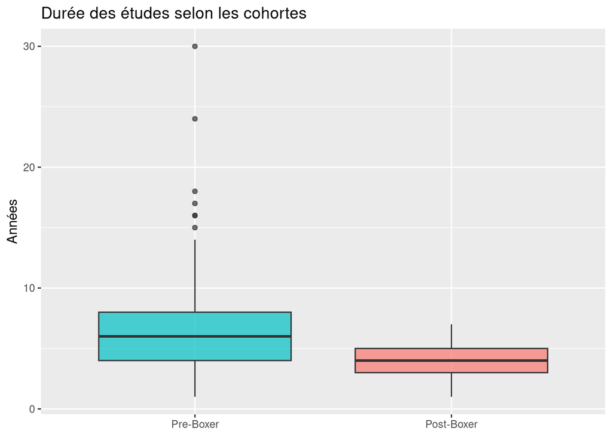

```r
# Autre périodisation

youmei_clean <- youmei_clean %>%
  mutate(
    generation2 = case_when(
      annee_arrivee_USA >= 1872 & annee_arrivee_USA <= 1908 ~ "Pre-Boxer",
      annee_arrivee_USA >= 1909 & annee_arrivee_USA <= 1917 ~ "Post-Boxer",
      TRUE ~ NA_character_   # pour les valeurs hors bornes
    )
  )

library(forcats)

youmei_clean %>%
  filter(!is.na(duree)) %>%
  ggplot(aes(x = fct_rev((generation2)), # inverser l'ordre des variables pour faire apparaître la génération la plus ancienne (pre-Boxer) en premier
             y = duree,
             fill = generation2)) +
  geom_boxplot(alpha = 0.7, show.legend = FALSE) +
  labs(title = "Durée des études selon les cohortes",
       x = NULL,
       y = "Années",
       fill = NULL)
```